# Indel Signature InsDel9

# InsDel9

**Note**

The XCT -> XT deletions may be related to APOBEC activity.

(corresponds to 83-type signature C_ID9)

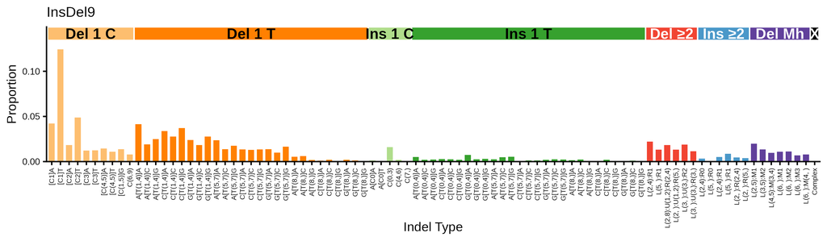

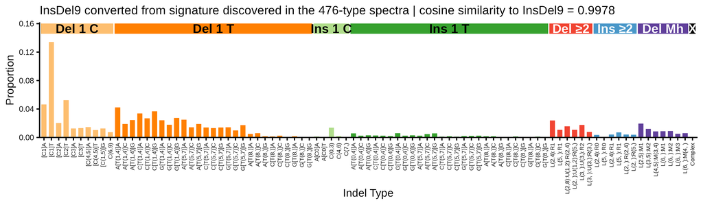

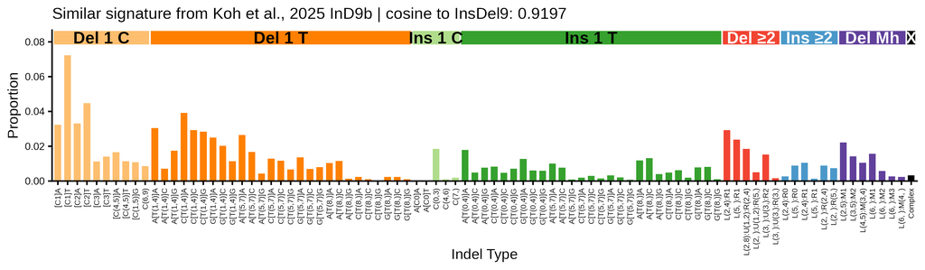

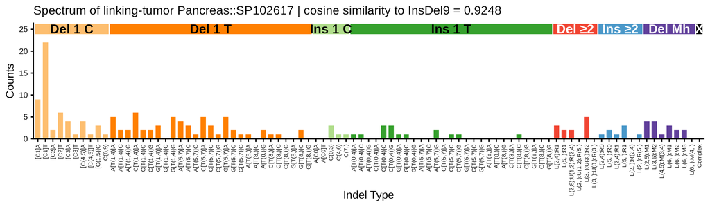

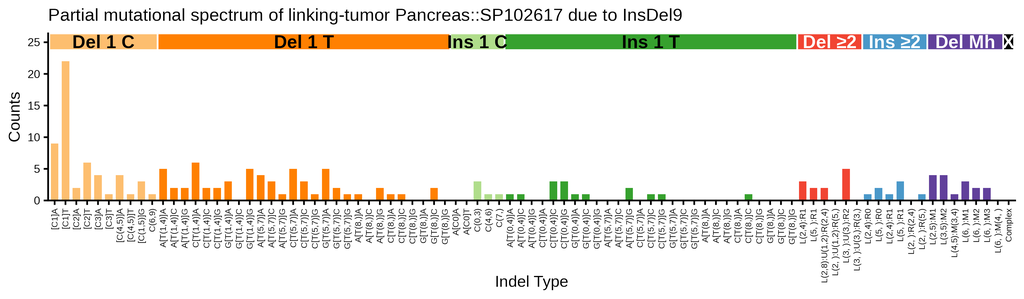

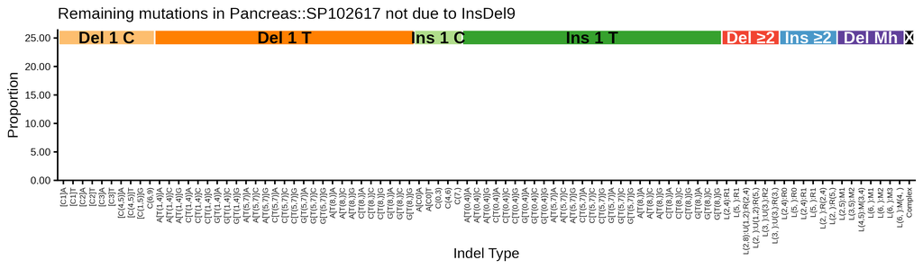

## 476-type representations corresponding to InsDel9

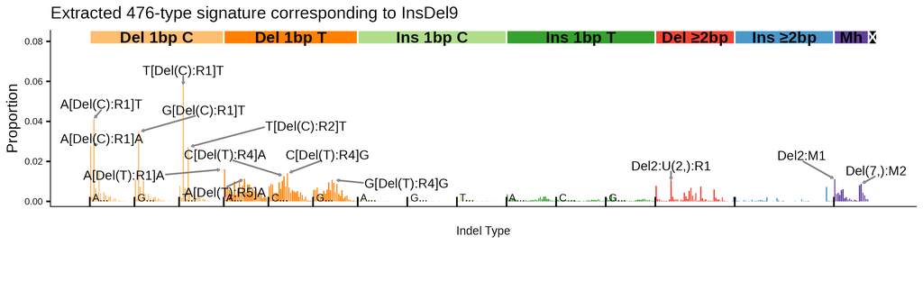

476-type spectrum of the linking tumor Pancreas::SP102617; cosine similarity to the extracted 476-type signature is 0.7863

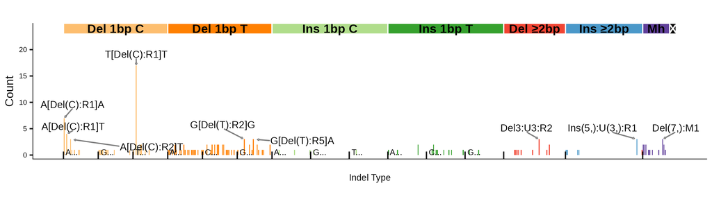

## 83-type signature corresponding to InsDel9 (C_ID9)

**Note**

Furthermore, Koh, Nanda, et al.’s extraction of a similar signature from 89-type spectra and our extraction from type-476 spectra that collapse to a similar 89-type signature indicate noticeable proportions of insertions of single Ts in long poly-T contexts.

ID9 also lacks insertions and deletions of sequences longer than 1 base, but these insertions and deletions are present in C_ID9 and in extractions from 89-type and 476-type spectra, which would seem to support C_ID9 versus ID9.

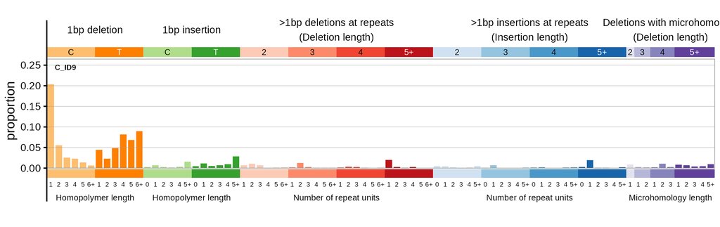

83-type signature converted from signature discovered in the 476-type spectra | cosine similarity to C_ID9: 0.9798

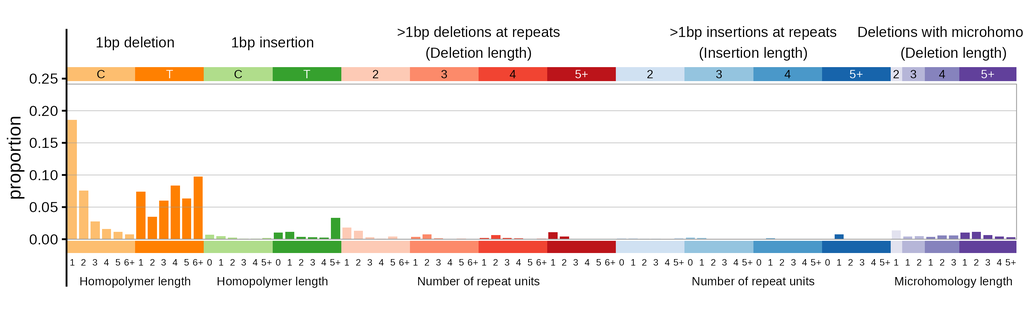

83-type spectrum of the linking tumor Pancreas::SP102617 | cosine similarly to C_ID9: 0.9508

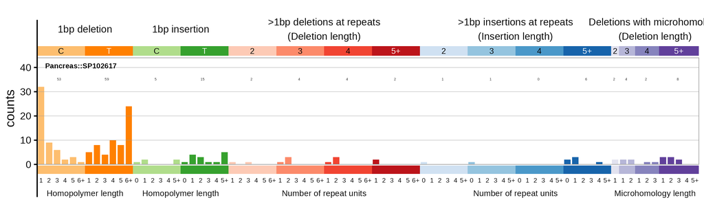

### Similar COSMIC signatures

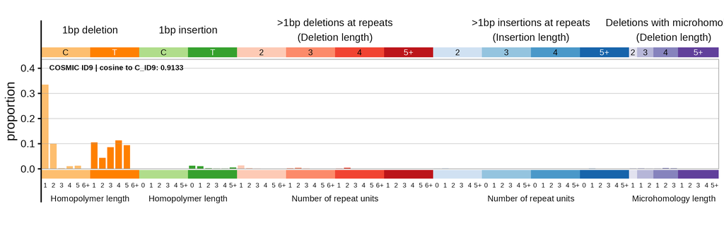